# Between Cell Variance

April Peterson

todo

-update the variable names

- re-run analyses with sd
- Cecile’s comment on transformations…

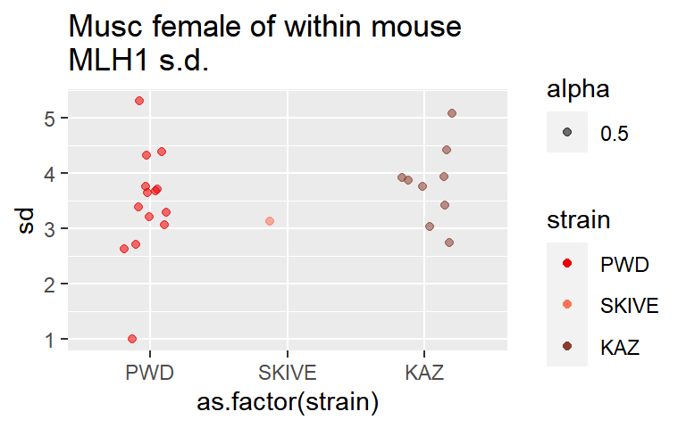

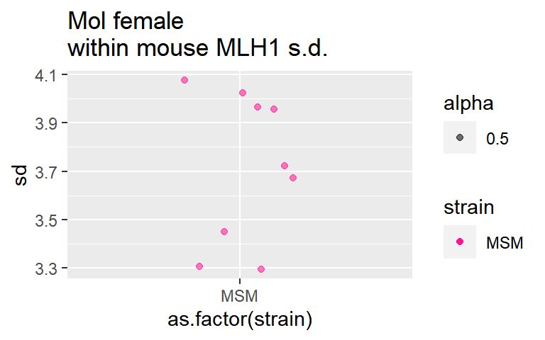

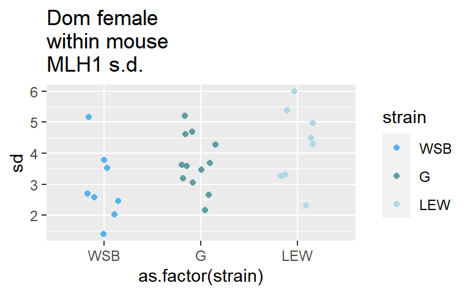

[figure not shown]

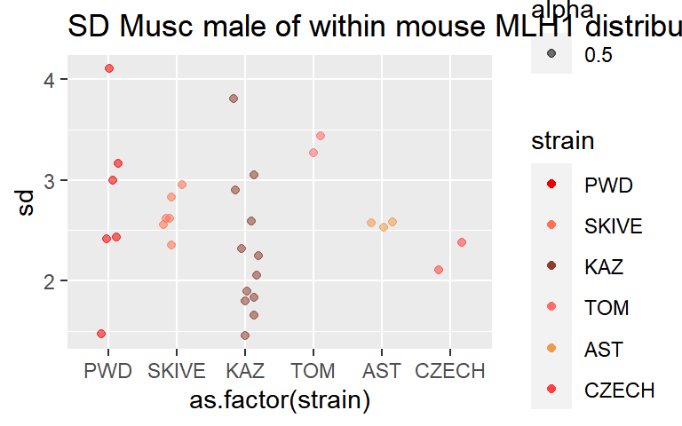

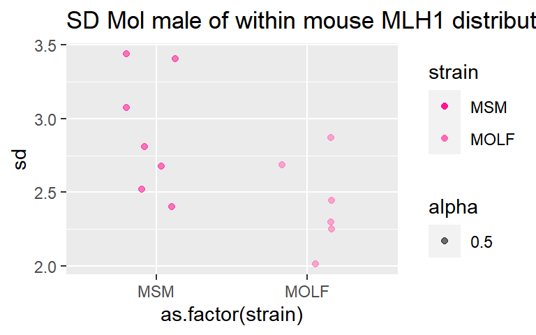

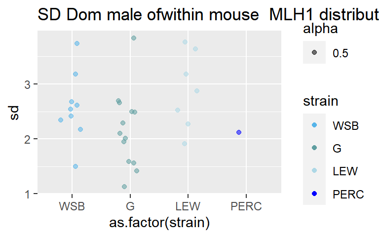

#Writing Outline

I find these results encouraging. The higher variance in females is visible across a variety of genetic backgrounds, including those in which females have lower means than males.

I feel like this result solidifies a plan for Chapter 3.

It could take the following basic form: Lower stringency of checkpoints during oogenesis predicts higher variance in crossover number within females Despite acceptance of this prediction, it has rarely been tested We tested the prediction across a wide array of genetic backgrounds Females consistently have higher variance than males in the same inbred line, with little evidence for line effects [Perhaps something about variance in SC length] In terms of recombination mechanisms, our results mean … In terms of evolutionary mechanisms, our results imply …

> How much do CO counts vary among cells from the same individual?

> What factors shape between-cell variance in CO count?

The approach will use the same glm models as in Chapter 2. A motivation for addressing these questions is that the variance of a quantitative trait can impact the evolution.

Below is the table for the number of cells per category by quality score. For this document just the cells with quality 1-2 will be used.

```
##
##     AST male CAROLI male CAST female CAST male CZECH male  F1 G female G male
##   1        7          10           0        13          3   5       98    138
##   2       11          19           0        15          4  13       92     77
##   3       25          16           0        10         25  10       85     58
##   4       20          12           1         6         30   2       43     23
##   5       15           9           0         5         29   1       47     15
##
##     HMI male KAZ female KAZ male LEW female LEW male MOLF female MOLF male
##   1        2         54       48         17       33           0         9
##   2        8         49       70         36       78           3        31
##   3       13         46       90         48       87           1        45
##   4       21         35       56         46       55          17        34
##   5       10         22       38         29       34          13        32
##
##     MSM female MSM male PERC male PWD female PWD male SKIVE female SKIVE male
##   1         53       53         3         21       34            5         79
##   2         95       82        13         68       48            5         65
##   3         96       61         4         83       55           12         48
##   4         56       23         6         50       24           10         19
##   5         42       13         4         41       11            7          8
##
##     SPIC female SPIC male SPRET female SPRET male TOM male WSB female WSB male
##   1          11        24            0         18        0         14       40
##   2          34        52            0         42        0         47       52
##   3          26        44            1         27        3         86       53
##   4          26        13            1         16        7         54       46
##   5          33        15            6          9       12         46       19
```

# Q12 Variance Plots

The plots below show each point as a mouse-level CO count variance, calculated from Quality 1-2 cells. The number of cells per mouse is indicated by size.

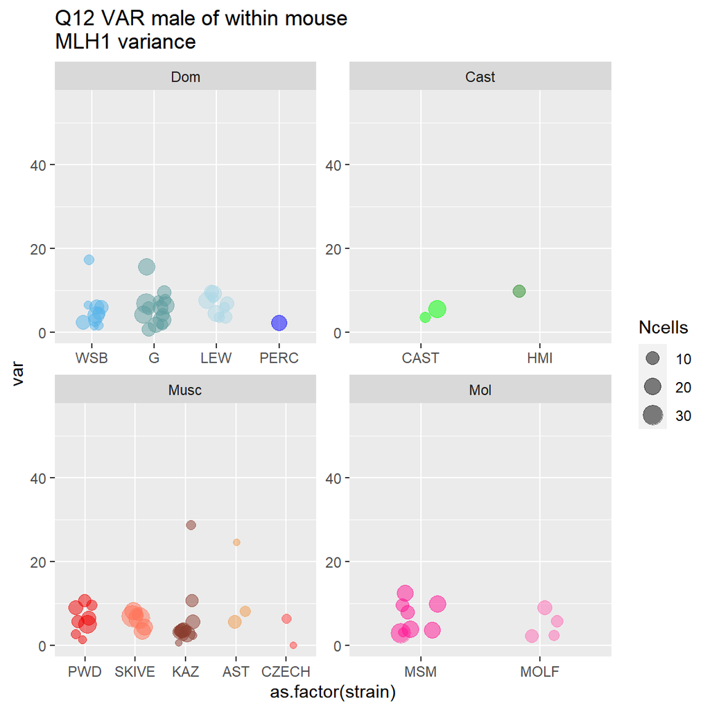

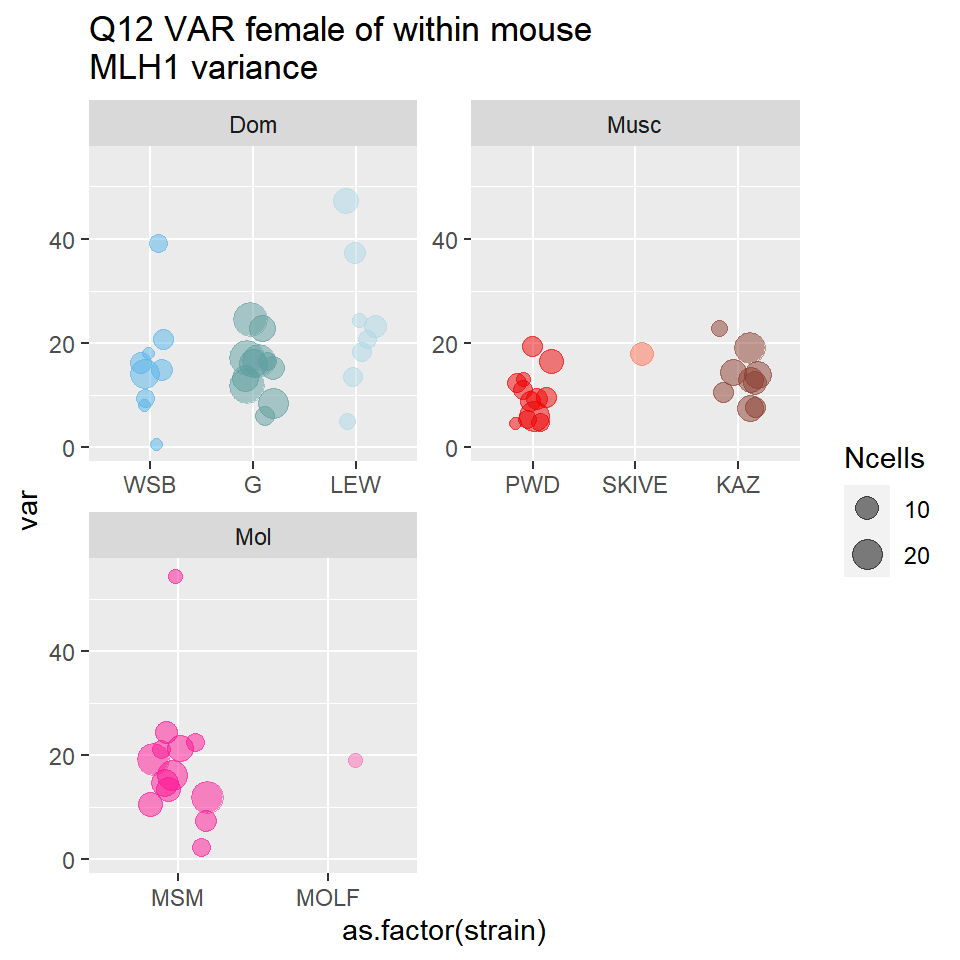

# observed values

These are the female strain variances: 16.44, 14.37, 28.52, 18.95, 11.47, 17.88, 16.67, the variance across strains (VAS) is 28.55.

These are the male strain variances: 7.24, 10.33, 8.09, 6.98, 8.26, 6.45, 5.55, the variance across strains (VAS) is 2.36. (For G, KAZ, LEW, MSM, PWD, SKIVE, WSB respectively)

# Mean and Variance correlations

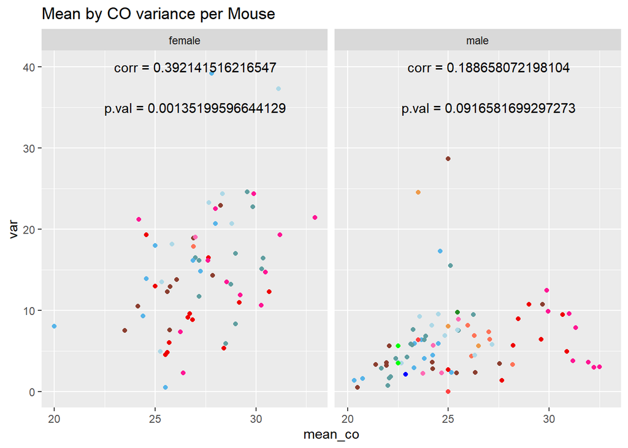

# Models MLH1(var)

The same glm models are being applied to variance and cV (M1 to M3) and sex specific models (M4 and M5). Out groups and strains with just one sex have been removed for M1-M3. Al factors are unordered.

**M1** Mixed model result for the mouse level for: subspecies, sex, interaction and strain 0.04, 9.110^{-12}, 0.06, 0.26. (Sex is the most significant).

**M2**

```
##                     Estimate Pr(>|t|)
## (Intercept)            15.61   0.0000
## subspMusc              -2.20   0.5121
## subspMol                3.39   0.6519
## sexmale               -10.40   0.0019
## strainG                -0.37   0.9083
## strainLEW               8.05   0.0215
## strainPWD              -3.40   0.2810
## strainMSM              -0.57   0.9385
## strainSKIVE             4.47   0.5519
## subspMusc:sexmale       2.65   0.5569
## subspMol:sexmale       -3.84   0.6556
## sexmale:strainG         0.89   0.8386
## sexmale:strainLEW      -6.74   0.1591
## sexmale:strainPWD       4.02   0.3707
## sexmale:strainMSM       2.45   0.7753
## sexmale:strainSKIVE    -4.05   0.6258
```

**M3**

```
##                     Estimate Pr(>|t|)
## (Intercept)            15.61   0.0000
## sexmale               -10.40   0.0019
## strainG                -0.37   0.9083
## strainLEW               8.05   0.0215
## strainPWD              -5.60   0.0766
## strainMSM               2.82   0.3625
## strainMOLF              3.39   0.6519
## strainSKIVE             2.27   0.7628
## strainKAZ              -2.20   0.5121
## sexmale:strainG         0.89   0.8386
## sexmale:strainLEW      -6.74   0.1591
## sexmale:strainPWD       6.67   0.1502
## sexmale:strainMSM      -1.39   0.7612
## sexmale:strainMOLF     -3.84   0.6556
## sexmale:strainSKIVE    -1.40   0.8671
## sexmale:strainKAZ       2.65   0.5569
```

**M4-M5 female**

```
##             Estimate Pr(>|t|)
## (Intercept)    15.61    0.000
## subspMusc      -2.20    0.615
## subspMol        3.39    0.729
## strainG        -0.37    0.930
## strainLEW       8.05    0.078
## strainPWD      -3.40    0.408
## strainMSM      -0.57    0.953
## strainSKIVE     4.47    0.648
```

```
##             Estimate Pr(>|t|)
## (Intercept)    15.61    0.000
## strainG        -0.37    0.930
## strainLEW       8.05    0.078
## strainPWD      -5.60    0.175
## strainMSM       2.82    0.485
## strainMOLF      3.39    0.729
## strainSKIVE     2.27    0.817
## strainKAZ      -2.20    0.615
```

Only the intercept’s are significant in the female specific models. None of the subsp or strain effects are significant.

**M4-M5 male**

```
##             Estimate Pr(>|t|)
## (Intercept)     5.21  0.00088
## subspCast       4.57  0.36038
## subspMusc      -2.04  0.57963
## subspMol       -0.45  0.87174
## strainG         0.52  0.79212
## strainLEW       1.31  0.54887
## strainPERC     -3.09  0.53570
## strainPWD       3.11  0.40876
## strainMSM       1.88  0.51846
## strainSKIVE     2.91  0.45418
## strainKAZ       2.48  0.49207
## strainAST       9.54  0.03066
## strainCAST     -5.23  0.37006
```

```
##             Estimate Pr(>|t|)
## (Intercept)     5.21  0.00088
## strainG         0.52  0.79212
## strainLEW       1.31  0.54887
## strainPERC     -3.09  0.53570
## strainPWD       1.07  0.63528
## strainMSM       1.43  0.52700
## strainMOLF     -0.45  0.87174
## strainSKIVE     0.87  0.72342
## strainKAZ       0.44  0.82469
## strainAST       7.50  0.01884
## strainCZECH    -2.04  0.57963
## strainCAST     -0.66  0.85777
## strainHMI       4.57  0.36038
```

# Models MLH1(cV)

**M1** Mixed model result for the mouse level for: subspecies, sex, interaction and strain 0.27, 3.4510^{-12}, 0.4, 0.22. (Sex is the most significant).

**M2**

```
##                     Estimate Pr(>|t|)
## (Intercept)            14.38  0.00000
## subspMusc              -0.56  0.72696
## subspMol                1.77  0.62266
## sexmale                -5.36  0.00082
## strainG                -1.04  0.49593
## strainLEW               2.28  0.17048
## strainPWD              -2.29  0.12865
## strainMSM              -1.92  0.58804
## strainSKIVE             1.90  0.59635
## subspMusc:sexmale       0.26  0.90383
## subspMol:sexmale       -2.32  0.57406
## sexmale:strainG         1.59  0.44599
## sexmale:strainLEW      -1.05  0.64518
## sexmale:strainPWD       1.93  0.37025
## sexmale:strainMSM       1.45  0.72316
## sexmale:strainSKIVE    -1.48  0.70870
```

**M3**

```
##                     Estimate Pr(>|t|)
## (Intercept)            14.38  0.00000
## sexmale                -5.36  0.00082
## strainG                -1.04  0.49593
## strainLEW               2.28  0.17048
## strainPWD              -2.86  0.05929
## strainMSM              -0.15  0.92009
## strainMOLF              1.77  0.62266
## strainSKIVE             1.34  0.70865
## strainKAZ              -0.56  0.72696
## sexmale:strainG         1.59  0.44599
## sexmale:strainLEW      -1.05  0.64518
## sexmale:strainPWD       2.19  0.32299
## sexmale:strainMSM      -0.86  0.69400
## sexmale:strainMOLF     -2.32  0.57406
## sexmale:strainSKIVE    -1.22  0.76000
## sexmale:strainKAZ       0.26  0.90383
```

**M4-M5 female**

```
##             Estimate Pr(>|t|)
## (Intercept)    14.38     0.00
## subspMusc      -0.56     0.75
## subspMol        1.77     0.66
## strainG        -1.04     0.54
## strainLEW       2.28     0.22
## strainPWD      -2.29     0.17
## strainMSM      -1.92     0.63
## strainSKIVE     1.90     0.63
```

```
##             Estimate Pr(>|t|)
## (Intercept)    14.38    0.000
## strainG        -1.04    0.541
## strainLEW       2.28    0.219
## strainPWD      -2.86    0.092
## strainMSM      -0.15    0.928
## strainMOLF      1.77    0.658
## strainSKIVE     1.34    0.737
## strainKAZ      -0.56    0.754
```

Only the intercept’s are significant in the female specific models. None of the subsp or strain effects are significant.

**M4-M5 male**

[output not shown]

```
##             Estimate Pr(>|t|)
## (Intercept)     9.01    0.000
## strainG         0.55    0.690
## strainLEW       1.23    0.418
## strainPERC     -2.65    0.443
## strainPWD      -0.67    0.668
## strainMSM      -1.01    0.519
## strainMOLF     -0.55    0.778
## strainSKIVE     0.12    0.944
## strainKAZ      -0.30    0.828
## strainAST       4.76    0.031
## strainCZECH    -3.66    0.154
## strainCAST      0.40    0.876
## strainHMI       3.27    0.345
```

# Permutations; MLH1

We’d like to know if the set of strains has bigger differences in between-cell variance than expected by chance. Your liner models provide one test, but they could suffer from small sample sizes per mouse. We can conduct a permutation test that enables you to pool all cells in each strain to increase the sample size.

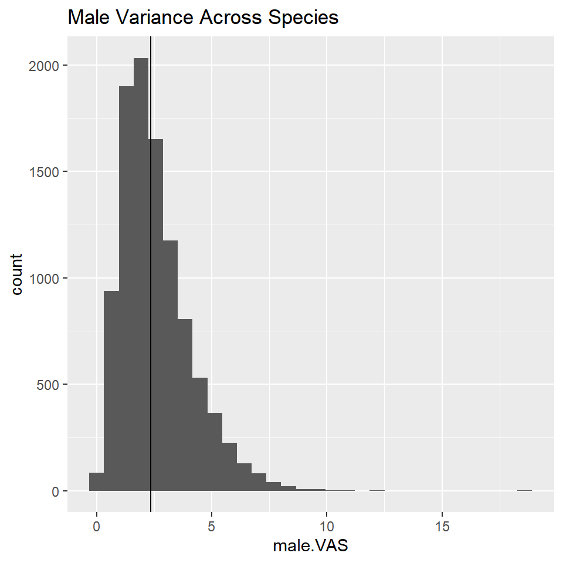

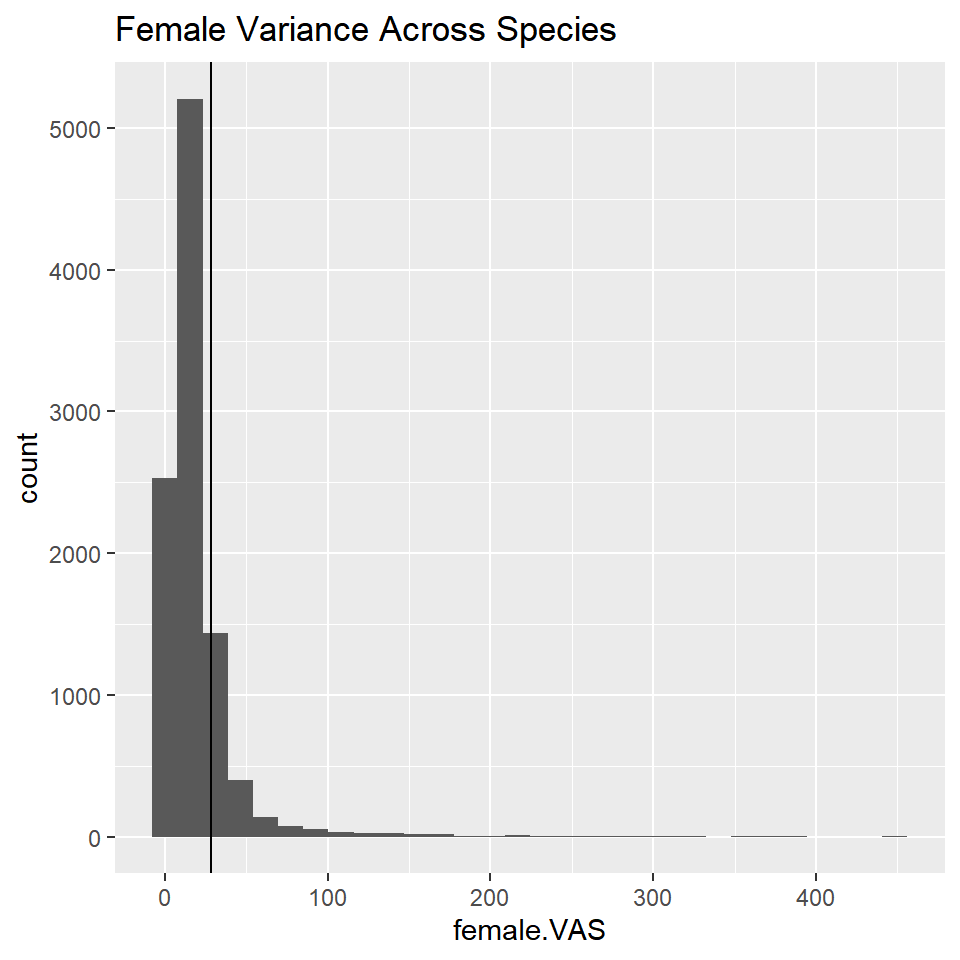

The plots above show the distributions of permuted VAS for 10,000 permutations, the vertical line shows the observed VAS.

The proportion of permutations which are less than the oberserved VAS are 0.53 and 0.85 for male and female respectively

# Permutations: var(F) - var(M)

1. Choose 1 strain.
2. Compute femaleVar-maleVar (pooling all high-quality cells within sexes for that strain).
3. Permute cells between sexes.
4. Compute femaleVar-maleVar for the permuted dataset.
5. Repeat 3-4 10,000 times.
6. Compare the observed value to the distribution of permuted values to compute a p-value.
7. Repeat 1-6 separately for each strain.

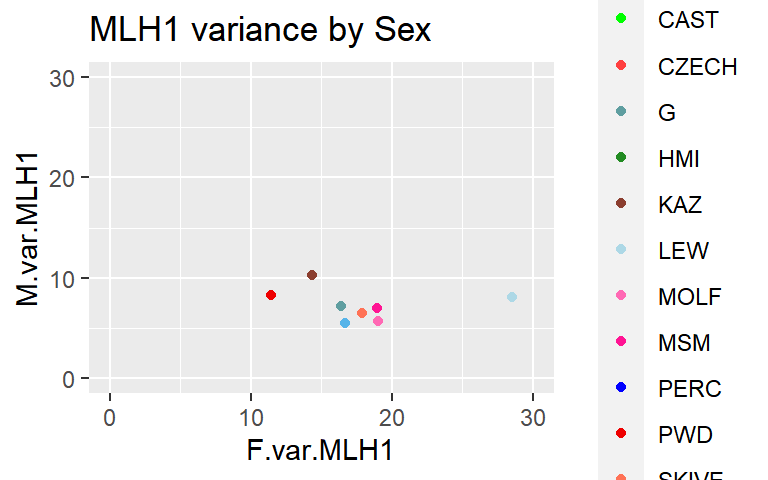

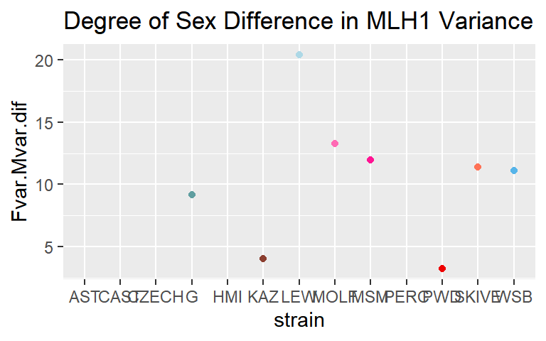

Above are the plots for observed sex differences for pooled cell variance. The first plot shows that all female values are higher than male, but PWD and KAZ have the lowest female variance and close to the highest male variance.

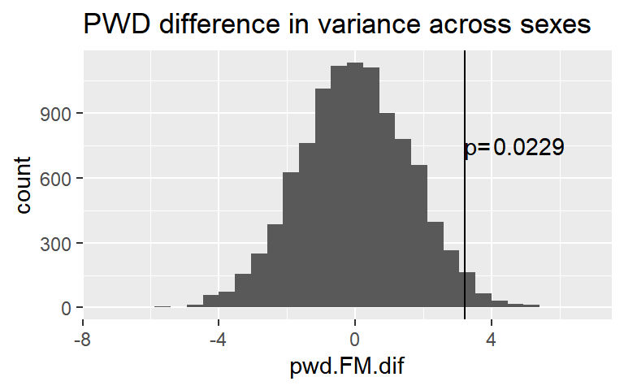

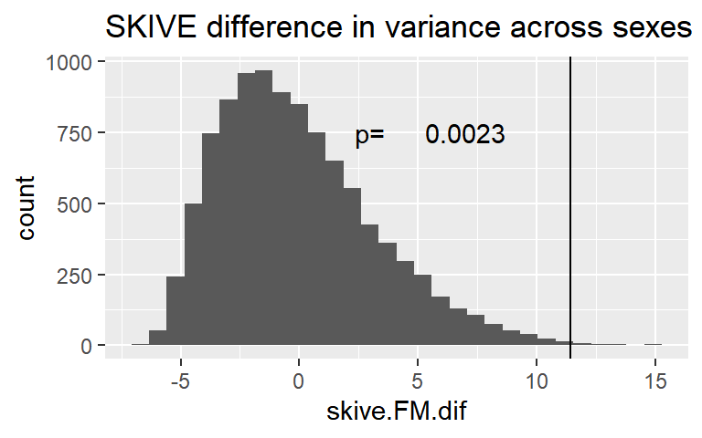

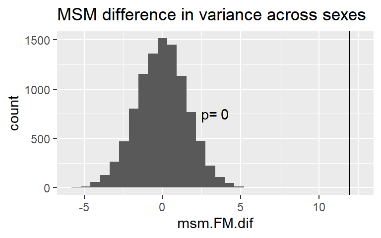

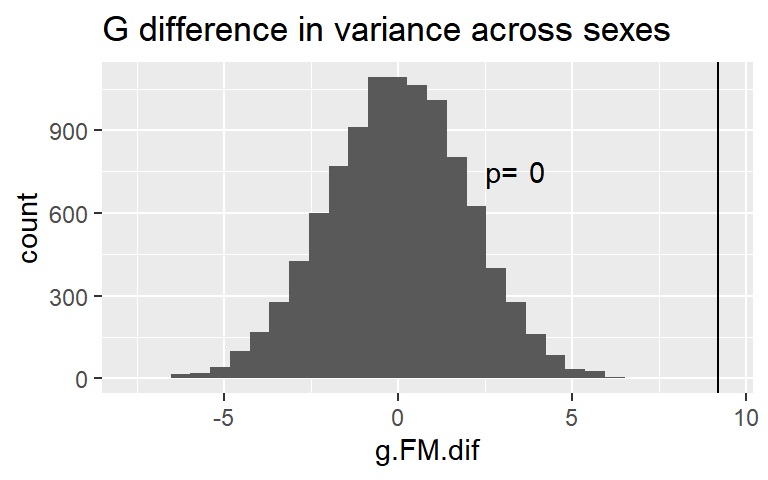

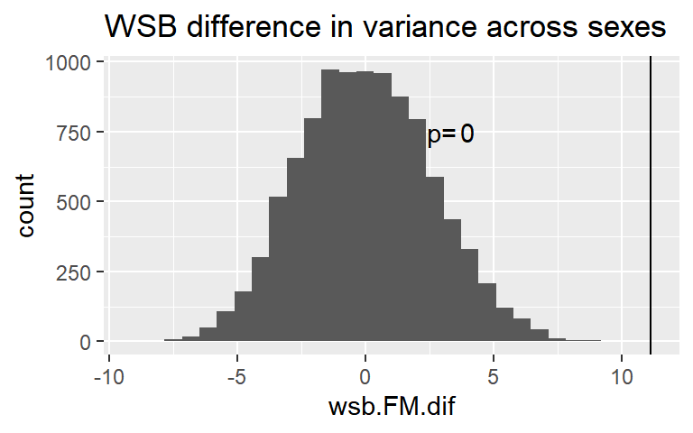

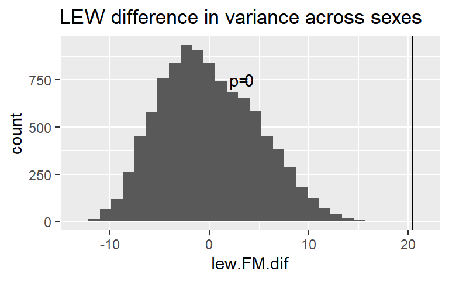

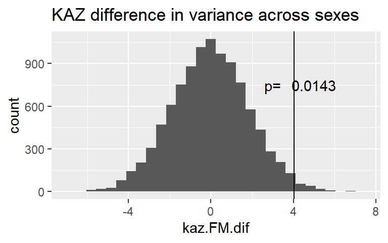

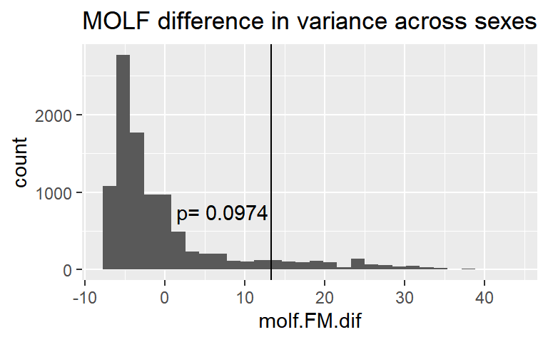

The above plots show the difference of Female.var - Male.var for n=10,000 permutations.

I should assess how these strain differences might be affected by the number of mice and cells, (espically MOLF).

# Total SC

I isolated cells with Q12 with MLH1 count and Skel measure. I removed rows that had a ‘yes’ for redo crop.

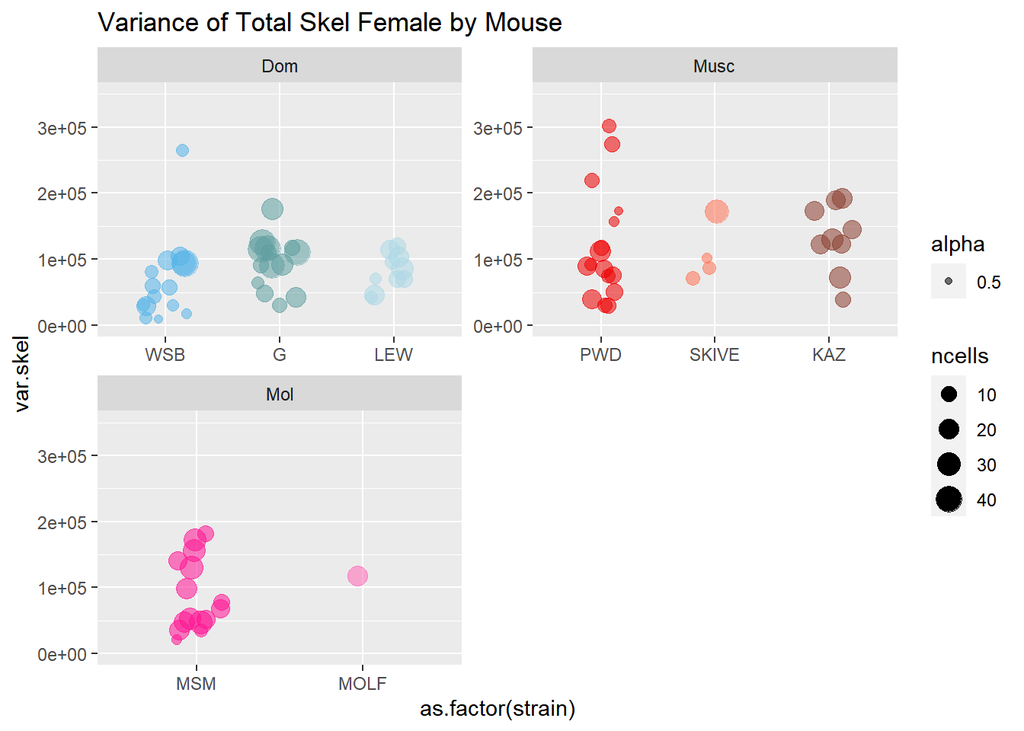

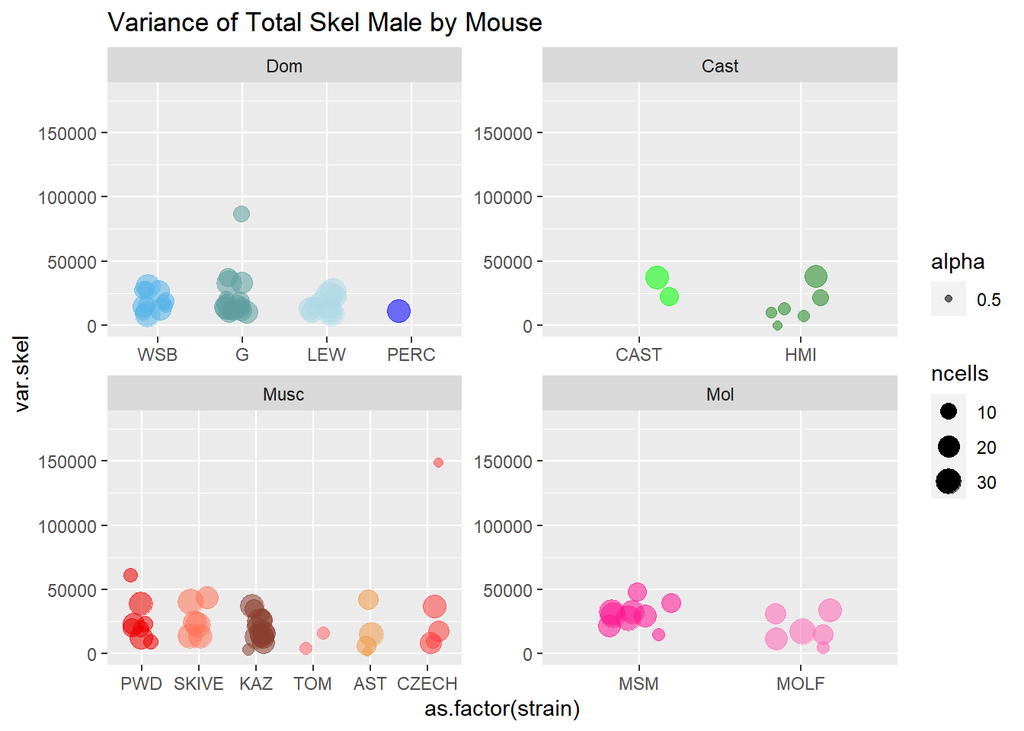

This is the number of cells per category

|  | AST | CAROLI | CAST | CZECH | F1 | G | HMI | KAZ | LEW | MOLF | MSM | PERC | PWD | SKIVE | SPIC | SPRET | TOM | WSB |
| --- | --- | --- | --- | --- | --- | --- | --- | --- | --- | --- | --- | --- | --- | --- | --- | --- | --- | --- |
| female | 0 | 0 | 0 | 0 | 0 | 184 | 0 | 102 | 52 | 3 | 140 | 0 | 73 | 11 | 36 | 0 | 0 | 60 |
| male | 17 | 23 | 27 | 8 | 16 | 199 | 8 | 114 | 97 | 39 | 114 | 14 | 66 | 106 | 64 | 56 | 0 | 79 |

These plots are for the number of mice

|  | WSB | G | LEW | PERC | PWD | MSM | MOLF | SKIVE | KAZ | TOM | AST | CZECH | CAST | HMI | SPRET | SPIC | CAROLI | F1 | other |
| --- | --- | --- | --- | --- | --- | --- | --- | --- | --- | --- | --- | --- | --- | --- | --- | --- | --- | --- | --- |
| female | 14 | 12 | 8 | 0 | 14 | 13 | 1 | 2 | 9 | 0 | 0 | 0 | 0 | 0 | 0 | 6 | 0 | 0 | 0 |
| male | 12 | 18 | 10 | 1 | 8 | 8 | 5 | 6 | 13 | 0 | 3 | 4 | 2 | 2 | 5 | 4 | 2 | 2 | 0 |

# Total SC Models of mouse-level variance

The same glm models are being applied to variance and cV (M1 to M3) and sex specific models (M4 and M5). Out groups and strains with just one sex have been removed for M1-M3. Al factors are unordered.

Changing the quality cut off I apply for the total SC dataset changes the significance of the sex coefficient.

**M1** Mixed model result for the mouse level for: subspecies, sex, interaction and strain. The p values for the total sc variance are as follow, 0, 1.110^{-21}, 0.02, 1. There are significant subspecies, sex and interaction effects, (but no significant strain effects). This uses the larger dataset for total SC.

**M2**

```
##                     Estimate Pr(>|t|)
## (Intercept)            68157   0.0000
## subspMusc              54026   0.1485
## subspMol               19635   0.2112
## sexmale               -49286   0.0035
## strainG                26910   0.0929
## strainLEW              13656   0.4359
## strainPWD              -2129   0.9543
## strainSKIVE           -14353   0.7298
## strainKAZ               9847   0.7625
## subspMusc:sexmale     -62882   0.0126
## subspMol:sexmale       -7995   0.7448
## sexmale:strainG       -24688   0.2751
## sexmale:strainLEW     -16237   0.5225
## sexmale:strainPWD      18084   0.4918
## sexmale:strainSKIVE    30508   0.3610
```

**M3**

```
##                     Estimate Pr(>|t|)
## (Intercept)            68157  0.00000
## sexmale               -49286  0.00346
## strainG                26910  0.09292
## strainLEW              13656  0.43591
## strainPWD              51897  0.00095
## strainMSM              19635  0.21115
## strainSKIVE            39673  0.10179
## strainKAZ              63874  0.00054
## strainTOM              -8856  0.78692
## sexmale:strainG       -24688  0.27507
## sexmale:strainLEW     -16237  0.52252
## sexmale:strainPWD     -44798  0.07377
## sexmale:strainMSM      -7995  0.74479
## sexmale:strainSKIVE   -32374  0.31682
## sexmale:strainKAZ     -62882  0.01260
```

Again most strain effects than sex effects.

**M4-M5 female**

```
##             Estimate Pr(>|t|)
## (Intercept)    68157  0.00002
## subspMusc      63874  0.01090
## subspMol       49572  0.41085
## strainG        26910  0.21601
## strainLEW      13656  0.56609
## strainPWD     -11977  0.62187
## strainMSM     -29936  0.61894
## strainSKIVE   -24200  0.48989
```

```
##             Estimate Pr(>|t|)
## (Intercept)    68157  0.00002
## strainG        26910  0.21601
## strainLEW      13656  0.56609
## strainPWD      51897  0.01504
## strainMSM      19635  0.35713
## strainMOLF     49572  0.41085
## strainSKIVE    39673  0.22825
## strainKAZ      63874  0.01090
```

**M4-M5 male**

```
##             Estimate Pr(>|t|)
## (Intercept)    18872  0.00047
## subspCast      -4010  0.65686
## subspMusc      25325  0.00969
## subspMol         -10  0.99911
## strainG         2222  0.74117
## strainLEW      -2581  0.73843
## strainPERC     -7356  0.69542
## strainPWD     -18226  0.07905
## strainMSM      11651  0.22249
## strainSKIVE   -18026  0.10159
## strainKAZ     -24333  0.01185
## strainTOM     -34181  0.02561
## strainAST     -27758  0.02383
## strainCAST     15094  0.30703
```

```
##             Estimate Pr(>|t|)
## (Intercept)    18872  0.00047
## strainG         2222  0.74117
## strainLEW      -2581  0.73843
## strainPERC     -7356  0.69542
## strainPWD       7099  0.38971
## strainMSM      11641  0.14589
## strainMOLF       -10  0.99911
## strainSKIVE     7299  0.41938
## strainKAZ        991  0.89083
## strainTOM      -8856  0.52097
## strainAST      -2433  0.81534
## strainCZECH    25325  0.00969
## strainCAST     11084  0.42210
## strainHMI      -4010  0.65686
```

# Direct tests of MLH1 and SC compaction

The Q12 dataset for MLH1 and the larger dataset for total SC are used in these models.

**MLH1variance = SCvariance * sex**

```
##             Estimate Pr(>|t|)
## (Intercept) 13.20371  0.00000
## var.skel     0.00003  0.12064
## sexmale     -6.94139  0.00055
```

**MLH1variance = SCmean * sex**

```
##             Estimate Pr(>|t|)
## (Intercept)   6.2820   0.4619
## mean.skel     0.0051   0.2552
## sexmale      -6.9745   0.0031
```

**MLH1variance = SCvariance * SCmean * sex**

```
##             Estimate Pr(>|t|)
## (Intercept)  8.70147    0.322
## mean.skel    0.00262    0.597
## var.skel     0.00002    0.239
## sexmale     -6.21199    0.011
```